# Introdução ao ggplot

dadosaleatorios

2018-09-13

Este material tem por objetivo passar uma idéia inicial das funcionalidades do pacote GGPLOT2 na visualização de dados.

O ggplot2 é um pacote de visualização de dados do R criado por Hadley Wickham.É uma implementação das ideias do livro *Grammar of Graphics* de Leland Wilkinson - que define a visualização de dados como a criação de gráficos estatísticos a partir de componentes semânticos como escalas e camadas.

O ggplot2 pode servir como um substituto para o gráfico base do R e contém vários padrões para exibição na web e impressão de escalas comuns.

Esses componentes semânticos(camadas) podem ser organizados conforme a descrição abaixo.

- Uma base de dados
- Atributos estéticos (aesthetics);
- Objetos geométricos;
- Transformações estatísticas;
- Escalas;
- Facetas; e,
- Demais ajustes.

Segue abaixo modelo de gráfico, utilizando a função do pacote **Base** e utilizando o pacote **GGPLOT2**

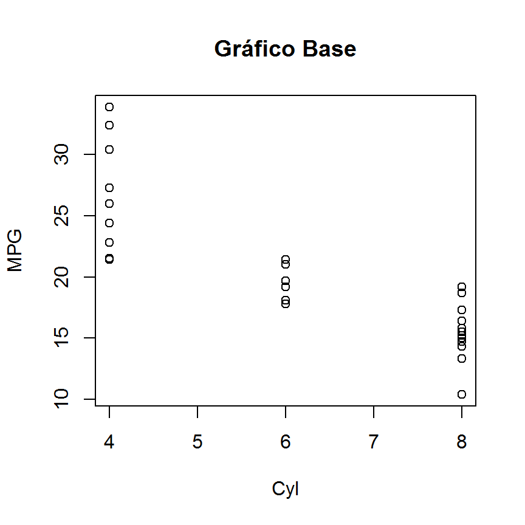

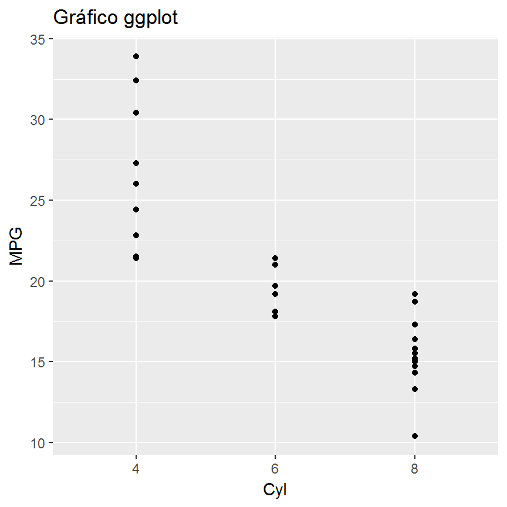

## Intalação do pacote

Para a utilização do pacote, devemos fazer a intalação e requisição do mesmo:

```r
install.packages("ggplot2")
require(ggplot2)
```

## Base de dados

A base de dados utilizada para exemplificar as funções do pacote é a base **mtcars**, dataset já existente no R, que traz informações de desempenho de 32 carros, do ano de 1974.

## Atributos estéticos

Os Atributos estéticos descrevem como as variáveis serão mapeadas nos dados para propriedades visuais (estéticas) dos geoms. Os mapeamentos estéticos podem ser definidos em ggplot2 e em camadas individuais.

Argumentos utilizados no **aes( )**:

- x e y: Observações que serão mapeadas
- color: Altera a cor das formas que não tem área (como retas e pontos)
- fill: altera a cor dos preenchimentos das formas com área
- size: altera o tamanho das formas
- alpha: altera a trasparência das formas
- labels: altera o nome das observações
- shape: altera o estilo das formas

## Objetos geométricos

Essa camada é utilizada para representar os pontos dos dados no gráfico. Existem muitos *geoms* disponíveis para representação dos dados. Aqui vamos explicitar os mais comumente utilizados:

| Tipo de Gráfico | Geom |
| --- | --- |
| scatterplot (gráfico de dispersão) | geom_point( ) |
| barchart (gráfico de barras) | geom_bar( ) |
| boxplot | geom_boxplot( ) |
| smooth (Curva suavizada) | geom_smooth( ) |

### Gráficos de Dispersão

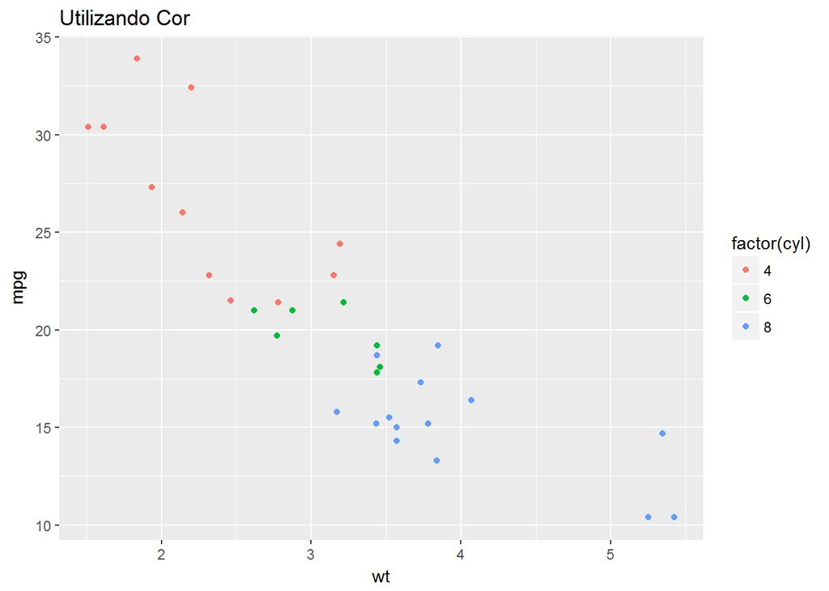

```r
p <- ggplot(mtcars, aes(wt, mpg))

p + geom_point(aes(colour = factor(cyl))) + ggtitle("Utilizando Cor")
```

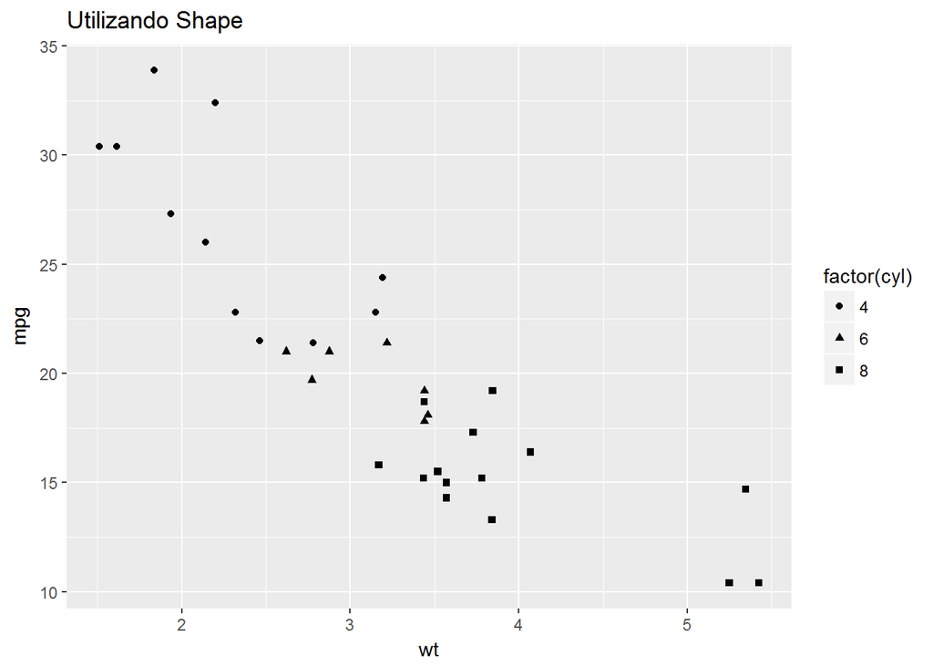

```r
p + geom_point(aes(shape = factor(cyl))) + ggtitle("Utilizando Shape")
```

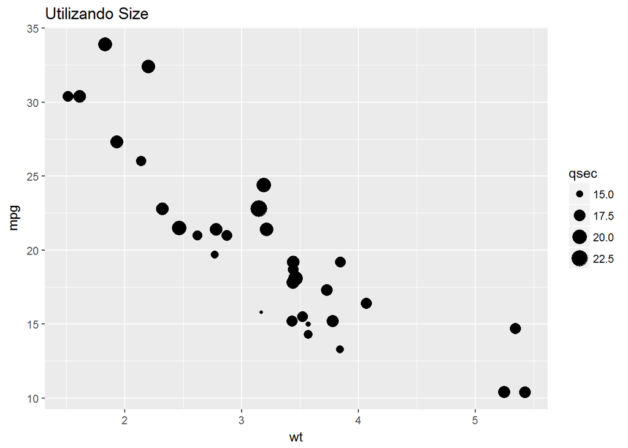

```r
p + geom_point(aes(size = qsec)) + ggtitle("Utilizando Size")
```

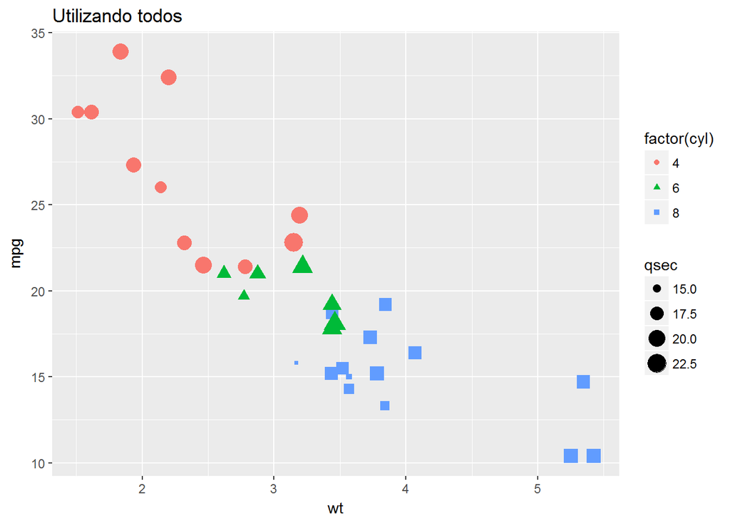

```r
p + geom_point(aes(colour = factor(cyl), size = qsec, shape = factor(cyl))) + ggtitle("Utilizando todos")
```

### Gráficos de Barras

Posição - Stack, Fill e Dodge

**Stack**: coloca as barras em cima umas das outras. Contagens são usadas. Esta é a posição padrão.

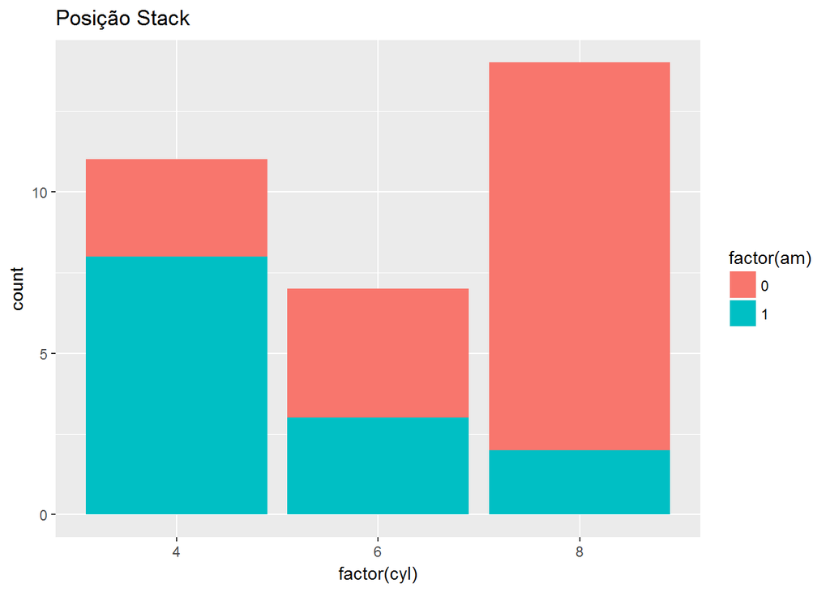

```r
ggplot(mtcars, aes(x = factor(cyl), fill = factor(am))) +
  geom_bar(position = "stack")+
  ggtitle("Posição Stack")
```

**Fill**: coloca as barras umas sobre as outras, mas desta vez usa proporções.

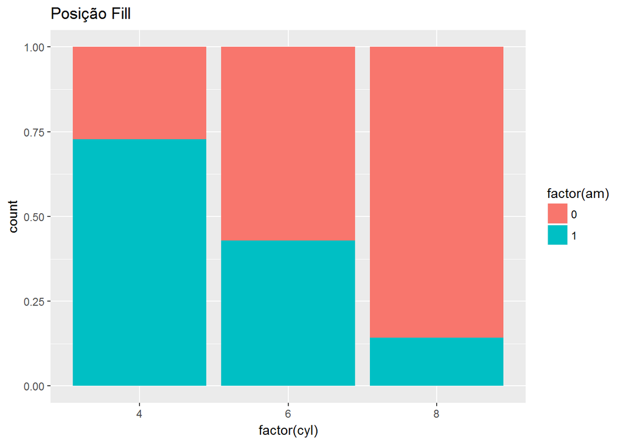

```r
ggplot(mtcars, aes(x = factor(cyl), fill = factor(am))) +
  geom_bar(position = "fill")+
  ggtitle("Posição Fill")
```

**Dodge**: coloca as barras uma ao lado da outra. Contagens são usadas.

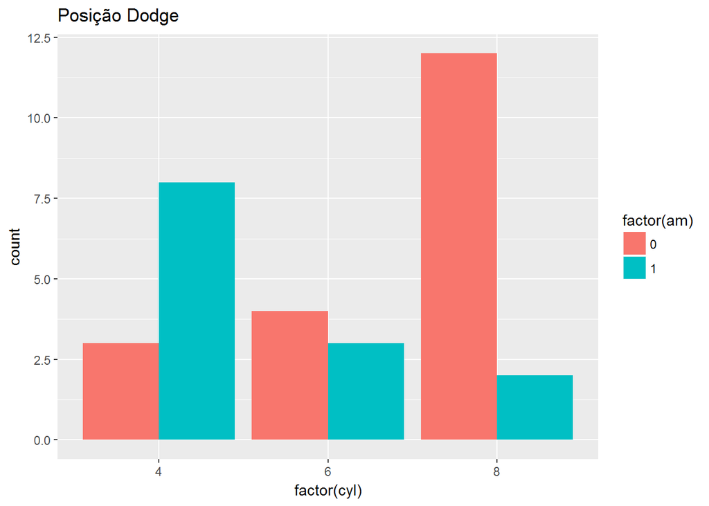

```r
ggplot(mtcars, aes(x = factor(cyl), fill = factor(am))) +
  geom_bar(position = "dodge") +
  ggtitle("Posição Dodge")
```

### Boxplot

Gráfico utilizado para visualizar compactamente a distribuição de uma variável contínua.

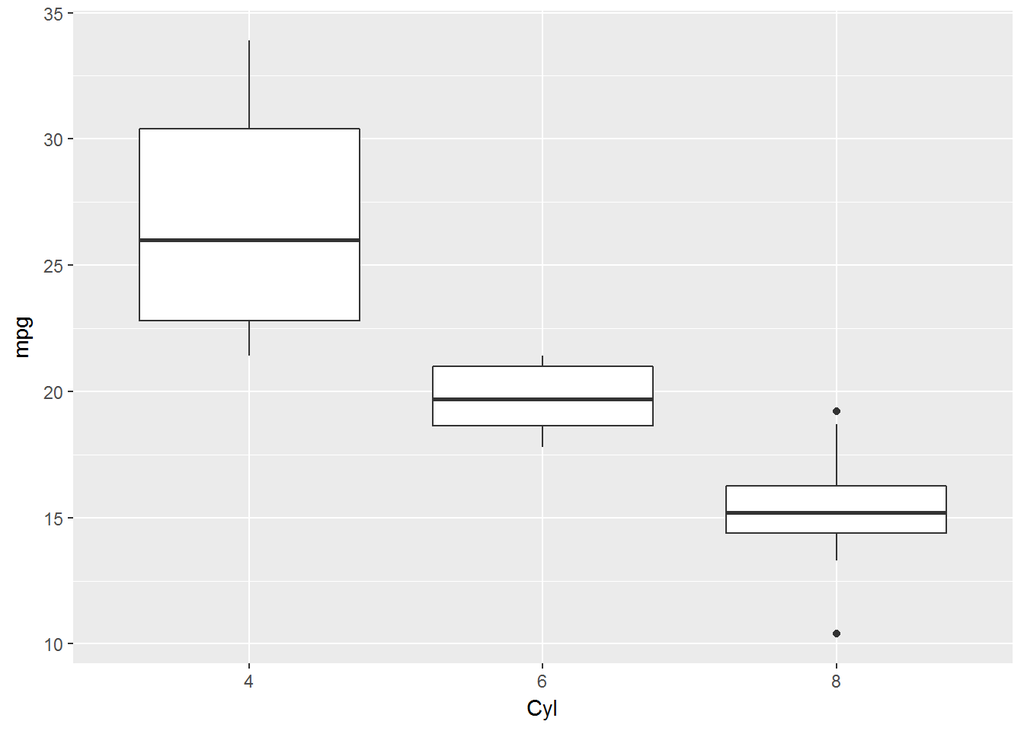

```r
ggplot(mtcars, aes(x = as.factor(cyl), y = mpg)) +
  geom_boxplot() +
  labs(x="Cyl")
```

### smooth(Curva suavizada)

Gráfico utilizado para analisar padrões de comportamento de uma variável, através da curva suavizada

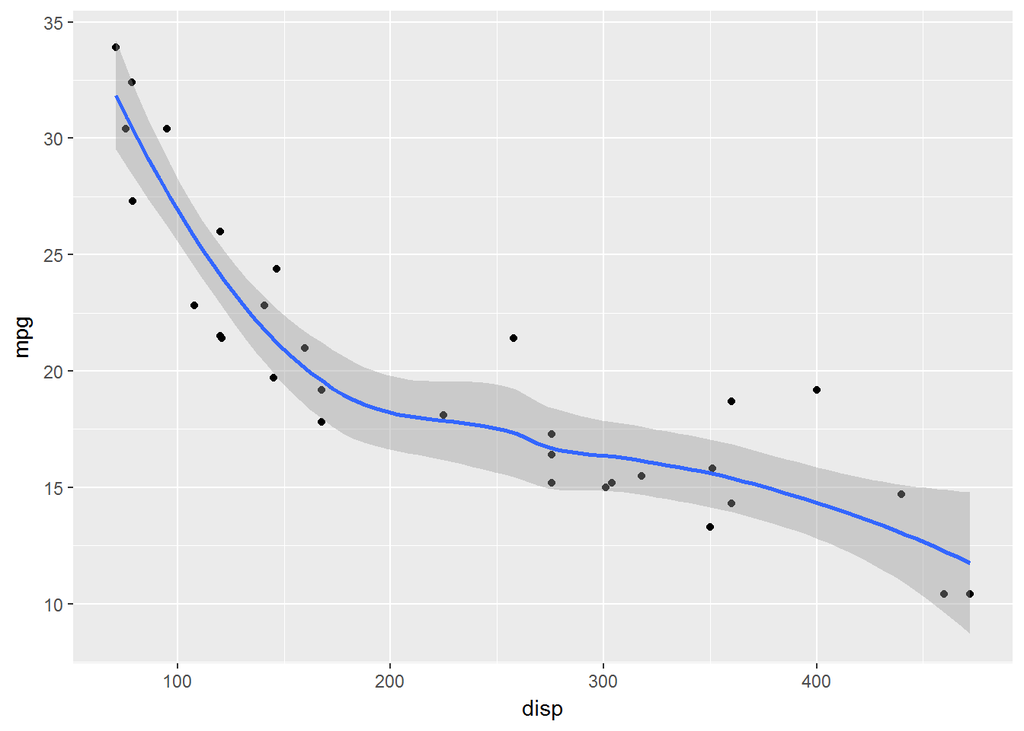

```r
ggplot(mtcars, aes(y = mpg, x = disp)) +
  geom_point() +
  geom_smooth()
```

Outros *geoms* utilizados:

- geom_abline(), geom_hline(), geom_vline - Adiciona linhas de referência: horizontal, vertical e diagonal.
- geom_label(), geom_text() - Adiciona e ajusta textos na plotagem.
- geom_polygon - Plota polígonos, preenchendo o interior (cores).
- Entre outros

## Transformações Estatísticas

Um punhado de camadas é mais facilmente especificado com uma função stat_, chamando a atenção para a transformação estatística em vez da aparência visual. Dentre suas funcionalidades, estão a de computar a distribuição cumulativa empírica, sumarizar os valores da variável, remover duplicadas, entre outros.

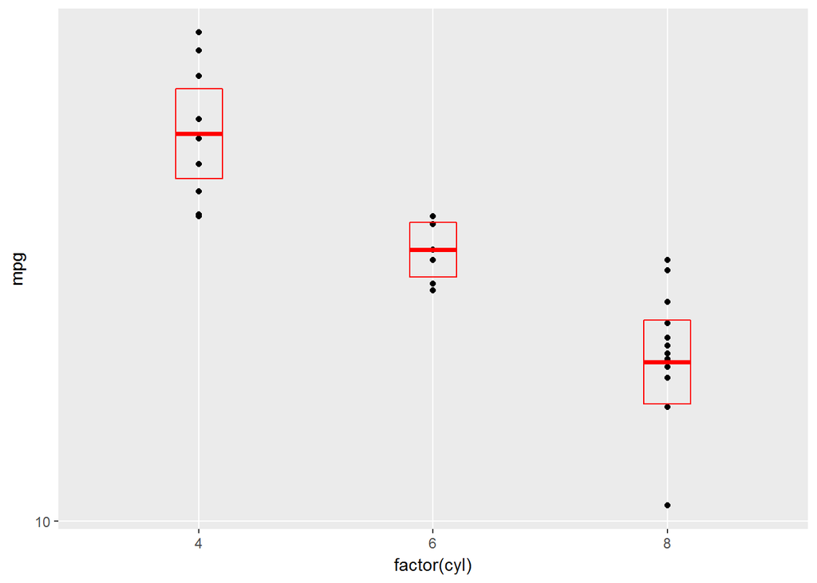

```r
ggplot(mtcars, aes(x = factor(cyl), y = mpg)) +
  geom_point() +
  stat_summary(fun.data = "mean_cl_normal", # função que retorna informações sumarizadas (resumo)
               geom = "crossbar", # Define o formato
               width = .2, # define largura
               col = "red") + # Define cor
  scale_y_log10()
```

Cada **stat** cria, se necessário, uma variável adicional que é mapeada para a estética (**aes()**). A sintaxe utilizada para a criação dessa nova variável é **..nome..**

Há várias outras funções para transformações estatísticas que podem ser utilizadas.

## Escalas

Bastante utilizada para substituir as escalas padrão e ajustar detalhes, como os rótulos dos eixos ou as chaves de legenda, ou para usar uma tradução completamente diferente dos dados para a estética.

Algumas funções que trabalham com a escala do gráfico:

- labs(), xlab(), ylab(), ggtitle() - Modificar rótulos de eixo, legenda e Título
- lims(), xlim(), ylim() - Definem os limites de escala do gráfico
- scale_x_continuous(), scale_y_continuous() - Escalas de dados para dados contínuos
- scale_x_discrete(), scale_y_discrete() - Escalas de posição para dados discretos
- Além de outros tipos de escala, como de cores, preenchimento, transparência.

## Coordenadas

Camada utilizada para modificar as estruturas dos eixos, seja delimitando -os ou o modificando sua visualização.

### coord_cartesian()

Define limites no sistema de coordenadas, aumentando o tamanho do gráfico, sem alteração nos dados.

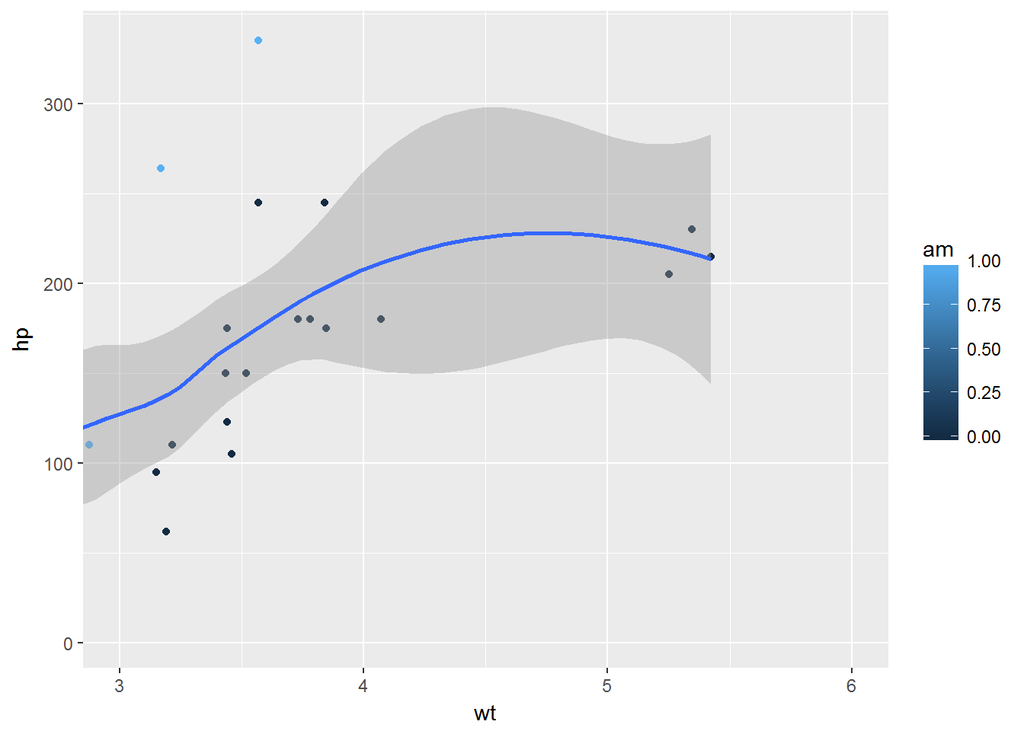

```r
ggplot(mtcars, aes(x = wt, y = hp, col = am)) +
  geom_point() +
  geom_smooth() +
coord_cartesian(xlim = c(3,6))
```

### coord_fixed()

Sistema de coordenada de escala fixa. representa o número de unidades no eixo y equivalente a uma unidade no eixo x. Garante que os intervalos de eixos sejam iguais.

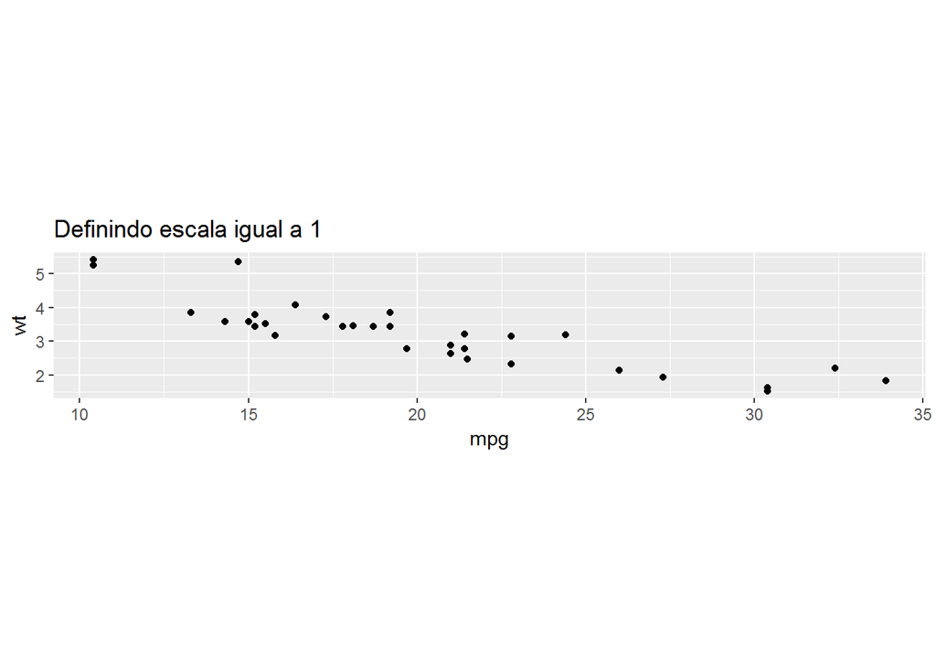

```r
ggplot(mtcars, aes(mpg, wt)) +
  geom_point() +
  coord_fixed(ratio = 1) +
  ggtitle("Definindo escala igual a 1")
```

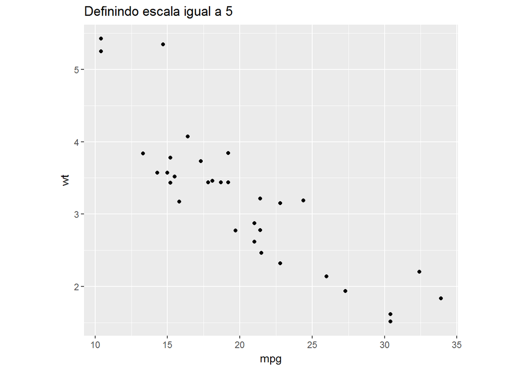

```r
ggplot(mtcars, aes(mpg, wt)) +
  geom_point() +
  coord_fixed(ratio = 5) +
  ggtitle("Definindo escala igual a 5")
```

### coord_polar()

converte um gráfico cartesiano planar x-y em coordenadas polares. Útil para produzir gráficos de setores.

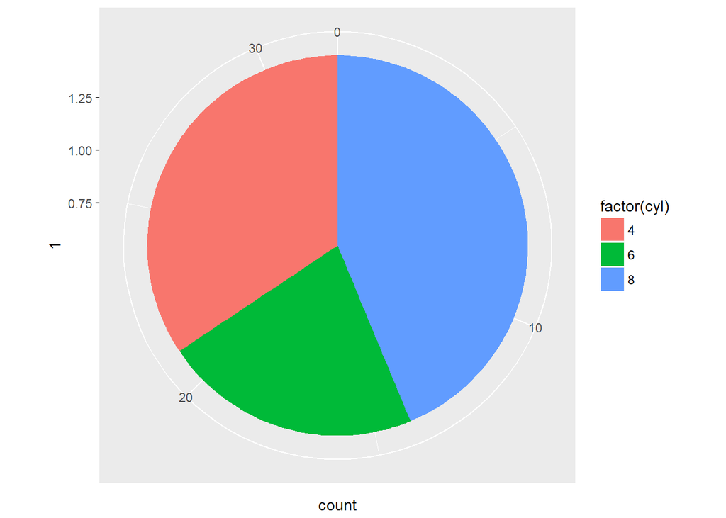

```r
thin.bar <- ggplot(mtcars, aes(x=1, fill = factor(cyl))) +
              geom_bar()

thin.bar +
  coord_polar(theta = "y")
```

### coord_flip()

Inverte coordenadas cartesianas para que a horizontal se torne vertical e vertical, horizontal.

##### Mudando a coordenada do gráfico de boxplot, gerado anteriormente

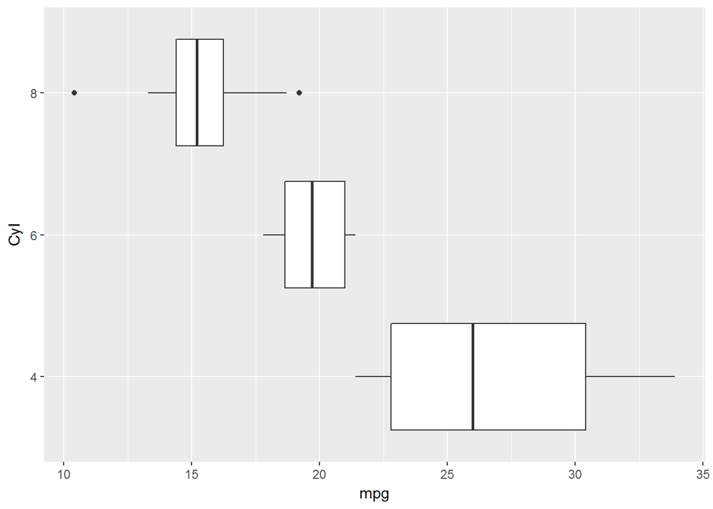

```r
ggplot(mtcars, aes(x = as.factor(cyl), y = mpg)) +
  geom_boxplot() +
  coord_flip() +
  labs(x="Cyl")
```

### coord_map

Utilizada para fazer projeções de mapas. Ajusta a imagem para projetar uma porção da terra, aproximadamente esférica

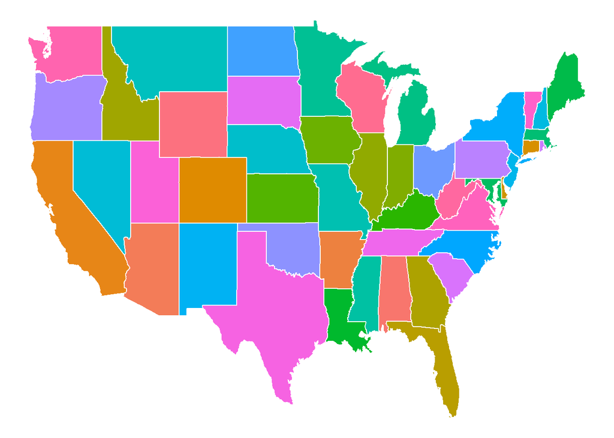

```r
state <- map_data("state")
ggplot(state, aes(x = long, y = lat, fill = region, group = group)) +
  geom_polygon(col = "white") +
  theme_nothing()
```

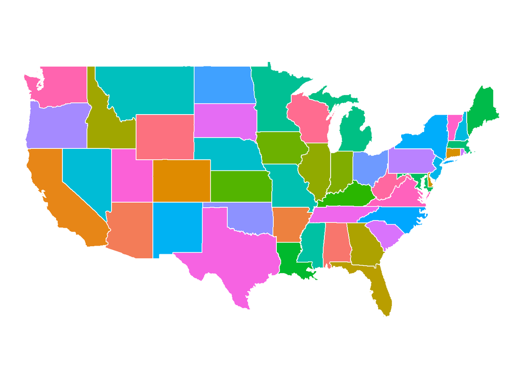

```r
ggplot(state, aes(x = long, y = lat, fill = region, group = group)) +
  geom_polygon(col = "white") +
  coord_map() +
  theme_nothing()
```

## Facets

Função utilizada para visualizar subconjuntos de dados em gráficos separados.

Tipos de facetas:

- **Facet grid** - Forma uma matriz de painéis definidos por variáveis na forma de linhas e colunas. É mais útil quando você tem duas variáveis discretas e todas as combinações das variáveis existem nos dados.
- **Facet wrap** - envolve uma sequência de painéis de 1d em 2d. Geralmente, esse é um uso melhor do espaço da tela do que facet_grid, porque a maioria dos plots é aproximadamente retangular.

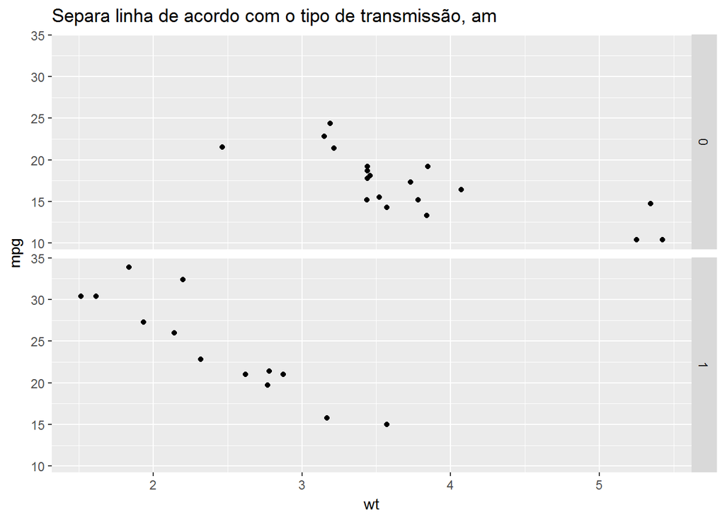

```r
p <- ggplot(mtcars, aes(x = wt, y = mpg)) +
  geom_point()

p + facet_grid(am ~ .) +
  ggtitle("Separa linha de acordo com o tipo de transmissão, am")
```

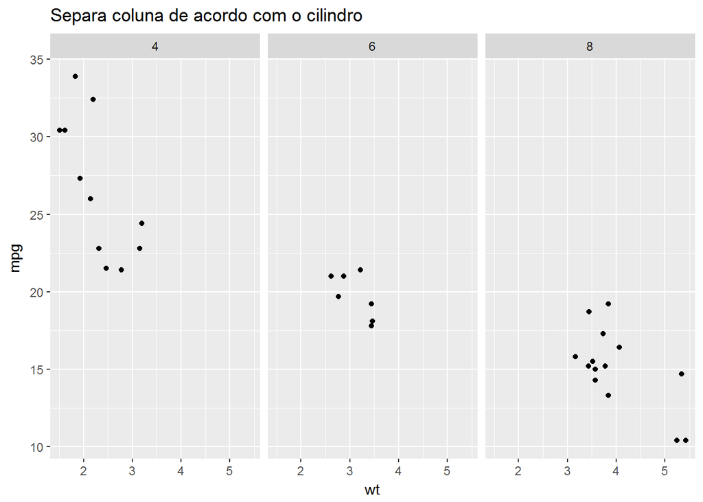

```r
p + facet_grid(. ~ cyl)+
  ggtitle("Separa coluna de acordo com o cilindro")
```

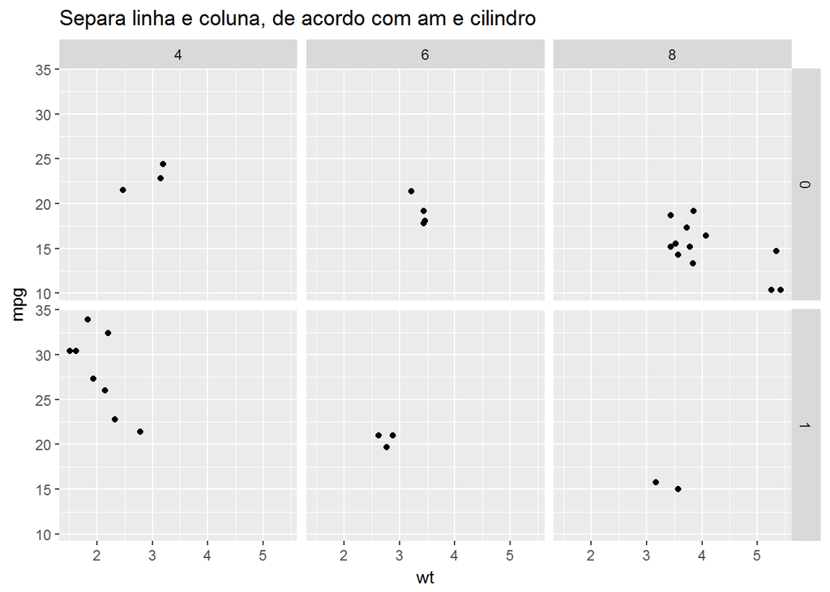

```r
p + facet_grid(am ~ cyl) +
  ggtitle("Separa linha e coluna, de acordo com am e cilindro")
```

## Temas

Os temas controlam a exibição de todos os elementos que não são de dados da plotagem. Você pode substituir todas as configurações por um tema completo como **theme_bw()** ou optar por ajustar configurações individuais usando **theme()** e as funções **element_**. Use **theme_set()** para modificar o tema ativo, afetando todos os gráficos futuros.

As funções mais utilizadas nas criações/modificações de temas são:

- element_line( ) - Modifica a aparência das linhas;
- element_text( ) - Modificar estrutura do texto;
- element_blank( ) - Não desenha nada e não atribui espaços
- theme( ) - Modifica o Layout da plotagem

### Exemplos

- Dentro do Tema, podemos modificar os painéis do gráfico:

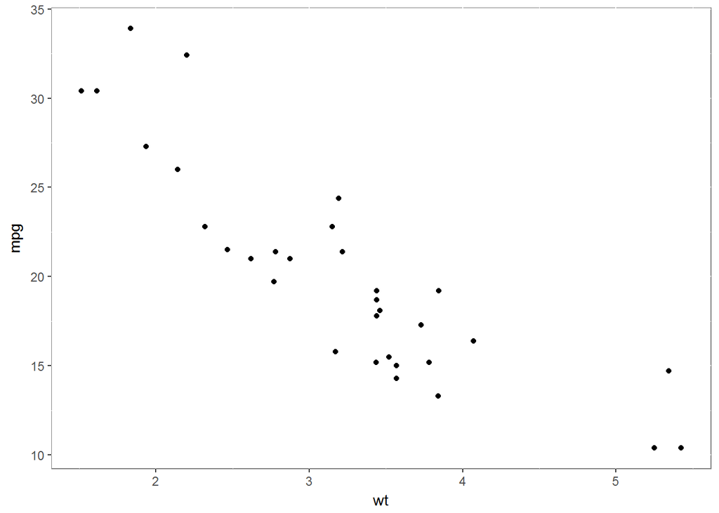

```r
p1 <- ggplot(mtcars, aes(wt, mpg)) +
  geom_point()
p1 + theme(panel.background = element_rect(fill = "white", colour = "grey50"))
```

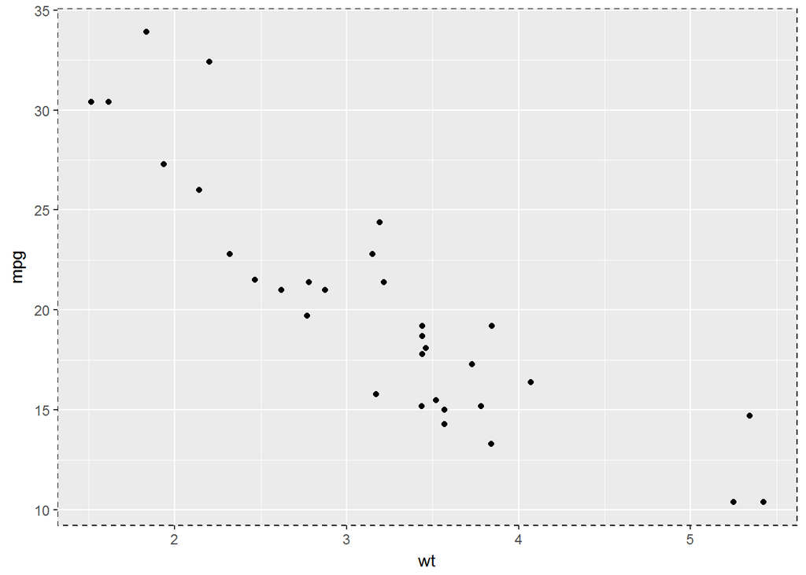

```r
p1 + theme(panel.border = element_rect(linetype = "dashed", fill = NA))
```

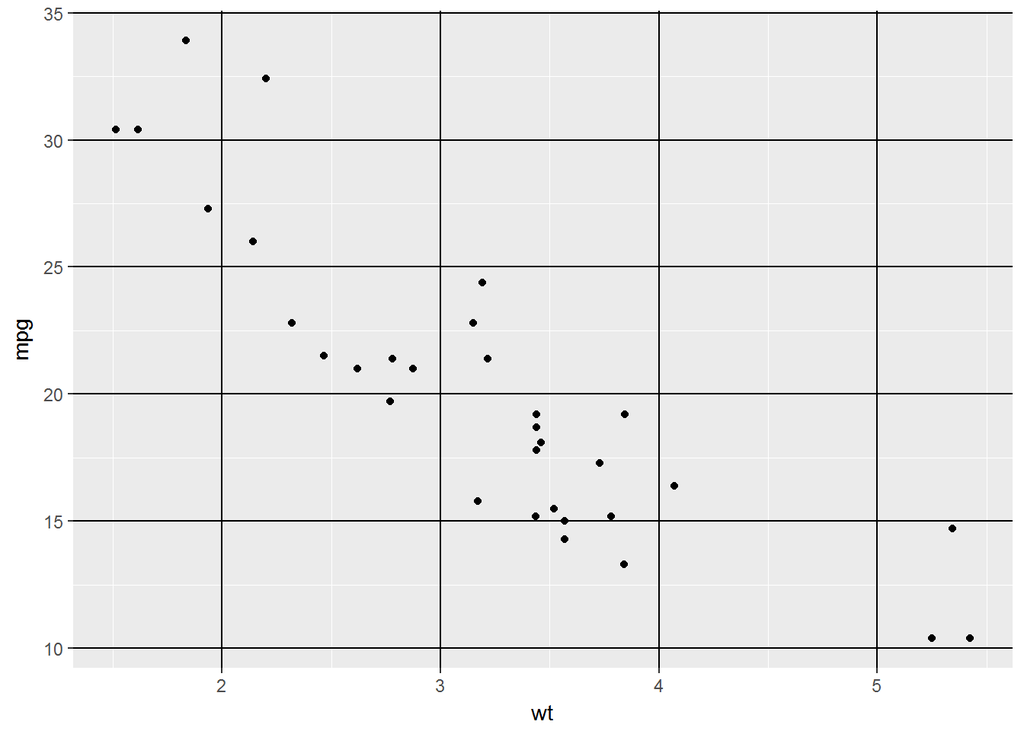

```r
p1 + theme(panel.grid.major = element_line(colour = "black"))
```

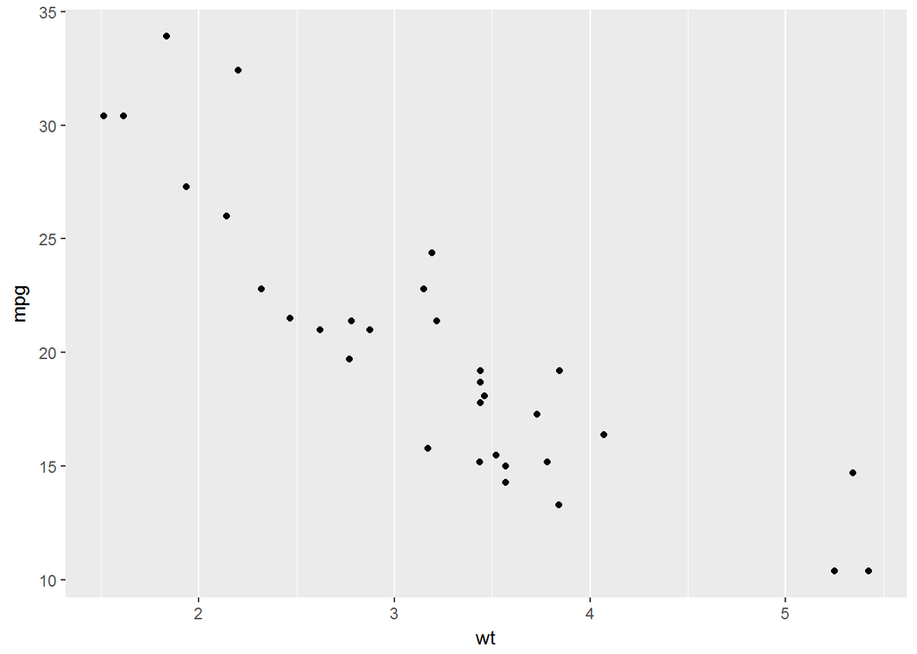

```r
p1 + theme(
  panel.grid.major.y = element_blank(),
  panel.grid.minor.y = element_blank()
)
```

- Podemos acrescentar grid

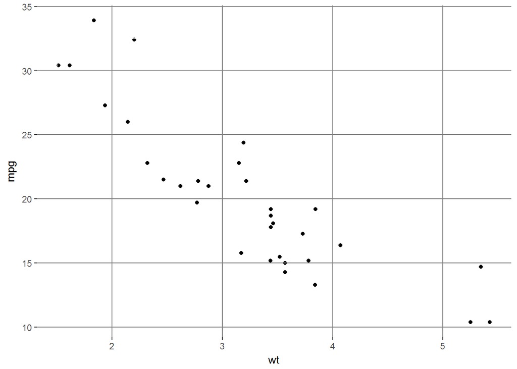

```r
p1 <- ggplot(mtcars, aes(wt, mpg)) +
  geom_point()

  p1 + theme(
  panel.background = element_rect(fill = NA),
  panel.grid.major = element_line(colour = "grey50"),
  panel.ontop = TRUE
)
```

- Podemos modificar os eixos

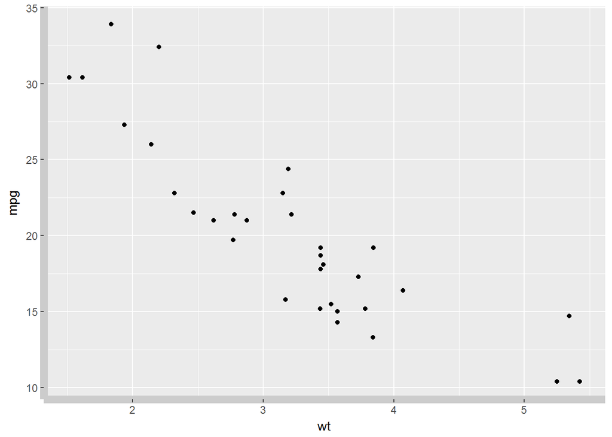

```r
p1 <- ggplot(mtcars, aes(wt, mpg)) +
  geom_point()
p1 + theme(axis.line = element_line(size = 3, colour = "grey80"))
```

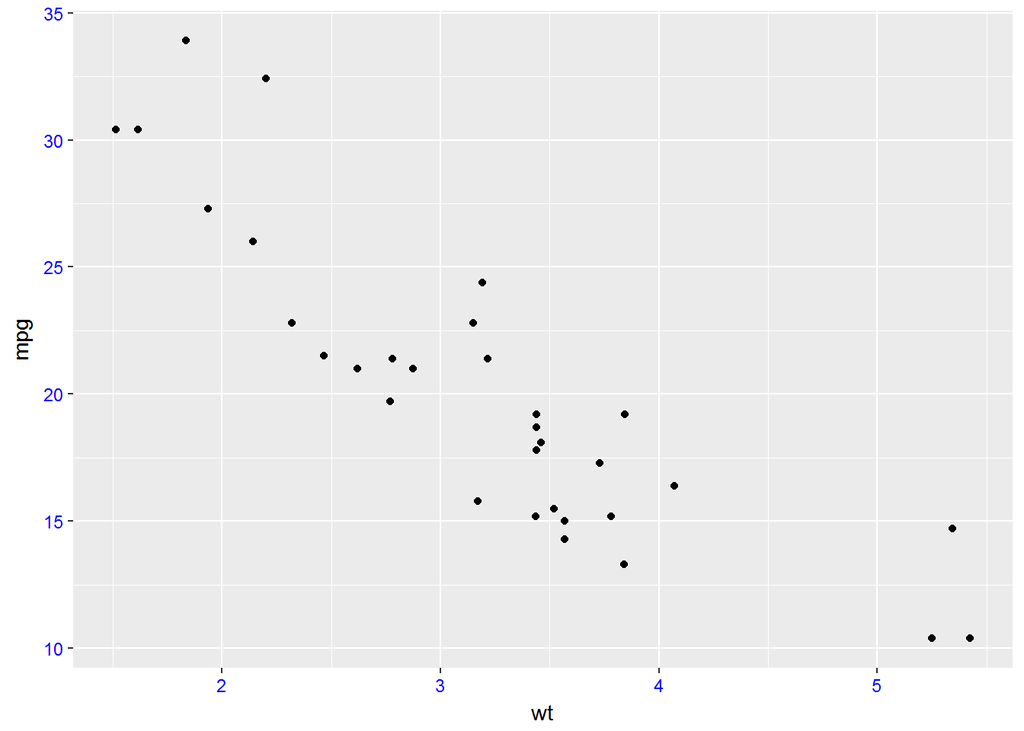

```r
p1 + theme(axis.text = element_text(colour = "blue"))
```

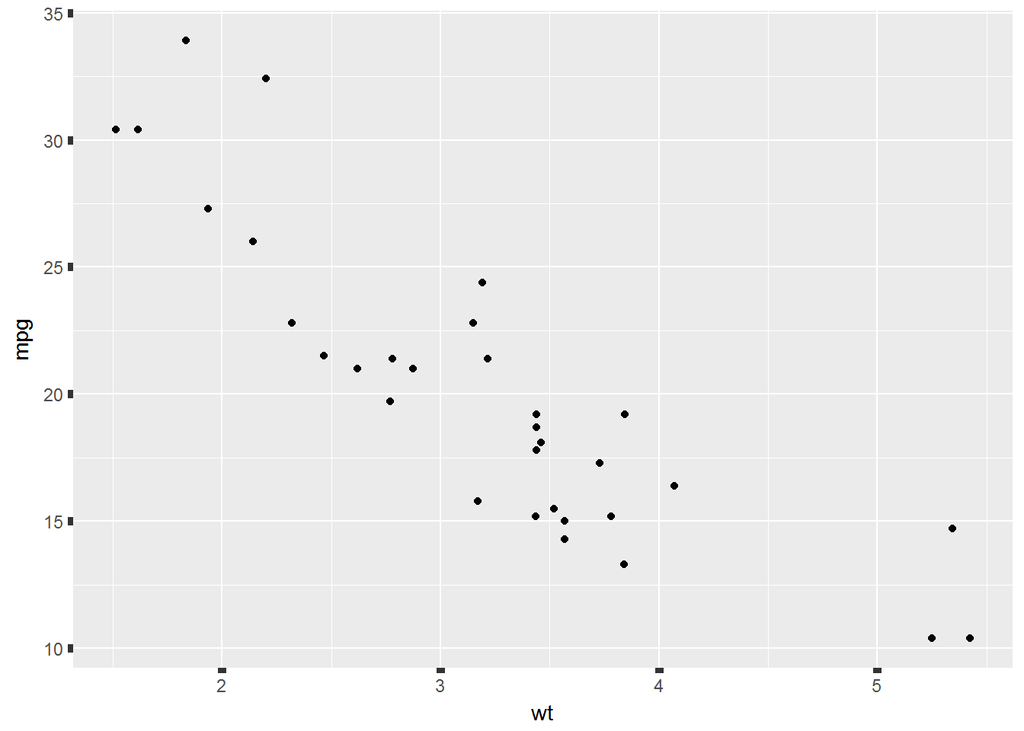

```r
p1 + theme(axis.ticks = element_line(size = 2))
```

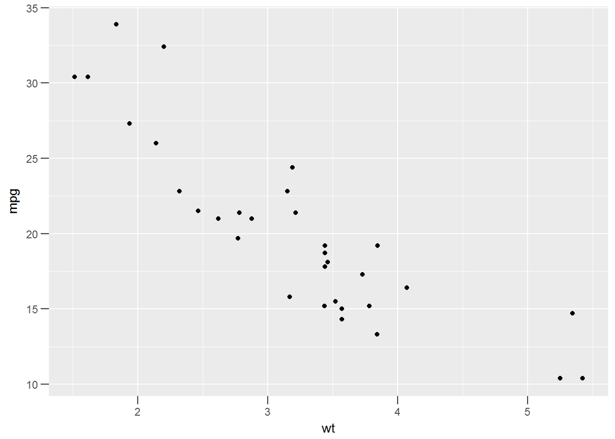

```r
p1 + theme(axis.ticks.length = unit(.25, "cm"))
```

- Podemos também modificar a legenda, quanto a sua posição

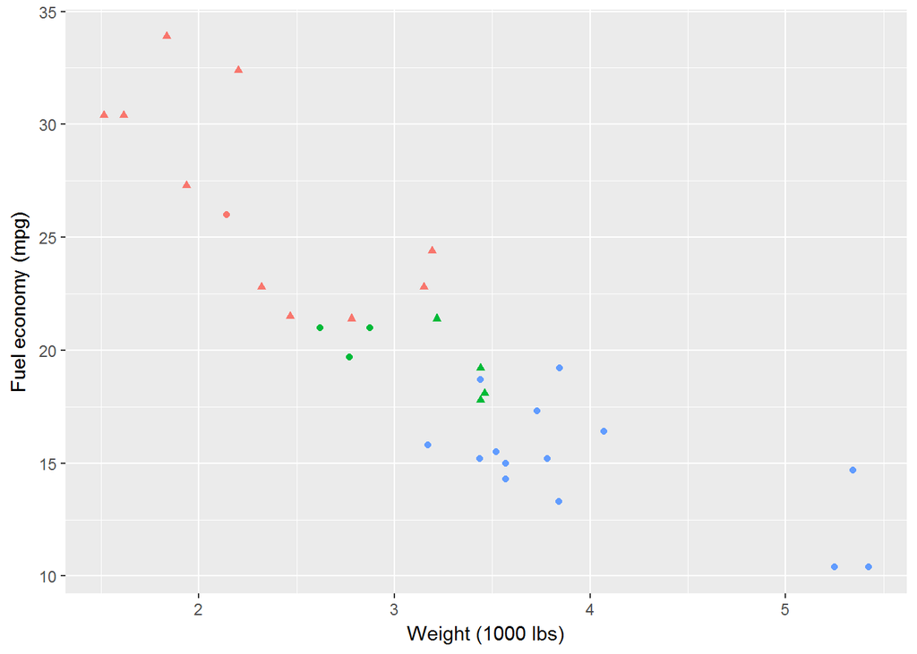

```r
p2 <- ggplot(mtcars, aes(wt, mpg)) +
  geom_point(aes(colour = factor(cyl), shape = factor(vs))) +
  labs(
    x = "Weight (1000 lbs)",
    y = "Fuel economy (mpg)",
    colour = "Cylinders",
    shape = "Transmission"
  )
p2 + theme(legend.position = "none")
```

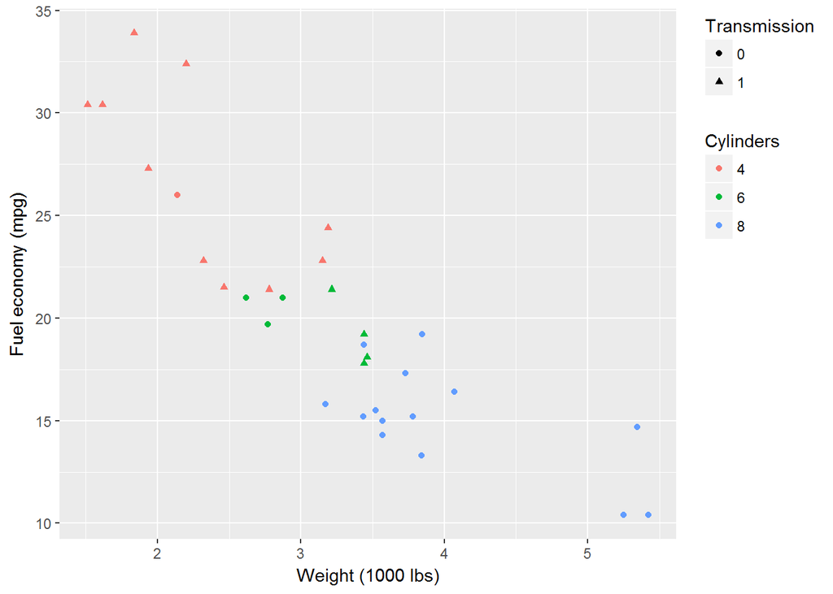

```r
p2 + theme(legend.justification = "top")
```

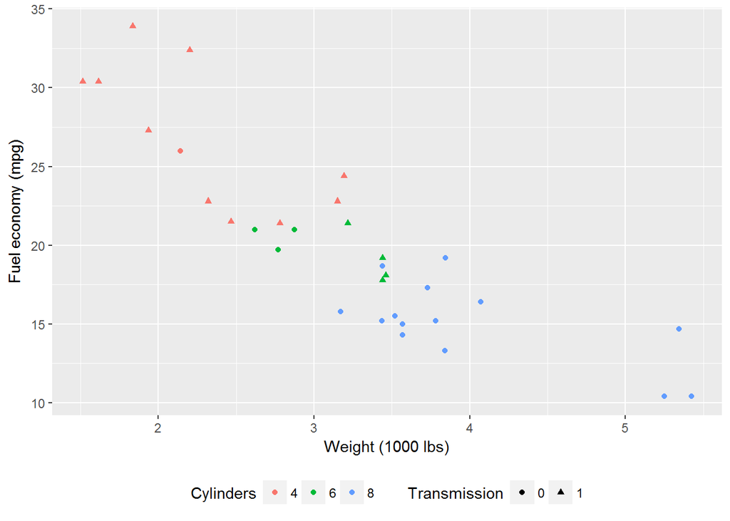

```r
p2 + theme(legend.position = "bottom")
```

## Plots para dados específicos

- Gráficos de densidade em 2D

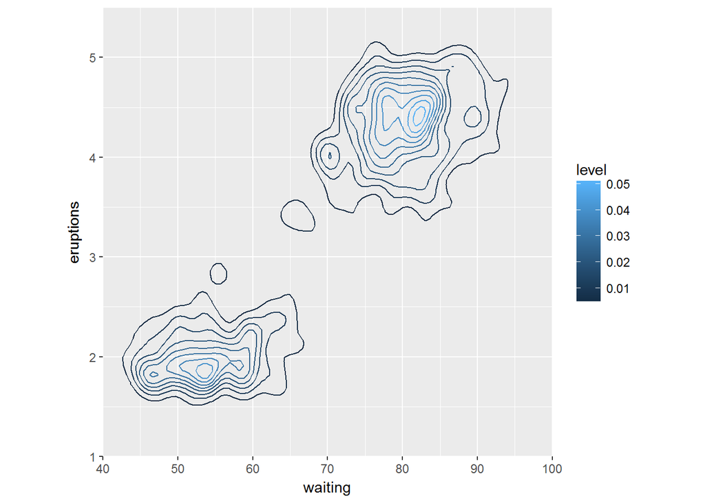

```r
p <- ggplot(faithful, aes(x = waiting, y = eruptions)) +
  scale_y_continuous(limits = c(1, 5.5), expand = c(0, 0)) +
  scale_x_continuous(limits = c(40, 100), expand = c(0, 0)) +
  coord_fixed(60 / 4.5)

p + stat_density_2d(aes(col = ..level..), h = c(5, .5))
```

- Gráficos de calor (Necessário a intalação do pacote “viridis”)

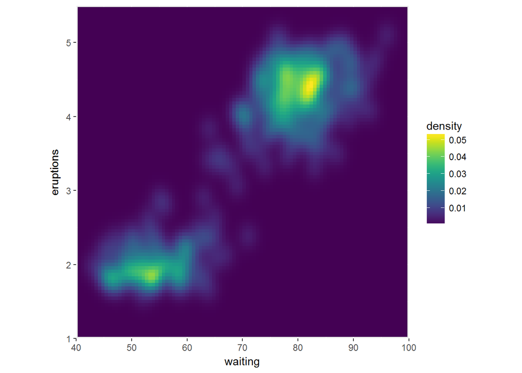

```r
ggplot(faithful, aes(x = waiting, y = eruptions)) +
  scale_y_continuous(limits = c(1, 5.5), expand = c(0,0)) +
  scale_x_continuous(limits = c(40, 100), expand = c(0,0)) +
  coord_fixed(60/4.5) +
  stat_density_2d(geom = "tile", aes(fill = ..density..), h=c(5,.5), contour = FALSE) +
  scale_fill_viridis()
```

## Extensões ggplot

O ggplot apresenta várias extensões disponíveis para explorar aspectos mais avançados em termos de visualização de dados:

- gganimate - Para criar gráficos ggplot2 animados.
- ggiraph - Gráficos interativos
- ggrepel - Modifica posição de texto para não sobrepôr
- Entre outros.

## Referências

#### https://www.datacamp.com/

#### http://ggplot2.tidyverse.org/index.html